# Tugas Semester Pembelajaran Mesin

Amiin Majiid Nugroho (17523105) & Habib Faizal Fadli (17523143)

## Naive Bayes Classifier Untuk Memprediksi Keputusan Pembeli Terhadap Pembelian Barang Tertentu

## Langkah-Langkah Penyelesaian

## 1. Kasus

Kasus yang digunakan merupakan dataset tentang customer behaviour. Data set diambil dari sini https://www.kaggle.com/denisadutca/customer-behaviour.

Dataset yang diambil adalah data customer behaviour yang berasal dari sebuah toko. Pada dataset tersebut berisikan 400 data dengan 5 variabel mulai dari User.ID, Gender, Age, Estimated Salary, dan Purchased.

Pada kasus kali ini akan membuat model Naive Bayes Classifier untuk melakukan prediksi terhadap keputusan customer apakah akan membeli (Purchased) produk tertentu pada toko atau tidak, dilihat dari 2 variabel yaitu Usia(Age) dan Penghasilan (Estimated Salary).

## Data set

Proses pertama yaitu melakukan proses membaca file csv dan memasukkannya ke dalam variabel myData. Lalu, untuk summary digunakan untuk memberikan ringkasan terkait isi dari data set.

```r
#import data set
myData <- read.csv(file = "D:/UII/Semester 6/Pembelajaran Mesin/Tugas/Tugas Semester/Tugas Semester/Customer_Behaviour.csv", header = TRUE)
head(myData)
```

|  | User.ID | Gender | Age | EstimatedSalary | Purchased |
| --- | --- | --- | --- | --- | --- |
| 1 | 15624510 | Male | 19 | 19000 | 0 |
| 2 | 15810944 | Male | 35 | 20000 | 0 |
| 3 | 15668575 | Female | 26 | 43000 | 0 |
| 4 | 15603246 | Female | 27 | 57000 | 0 |
| 5 | 15804002 | Male | 19 | 76000 | 0 |
| 6 | 15728773 | Male | 27 | 58000 | 0 |

Setelah kita melihat isi dari dataset tersebut, coba kita lihat summary data untuk melihat ringkasan dari datanya.

```r
#untuk melihat summary data
summary(myData)
```

```
##     User.ID            Gender               Age        EstimatedSalary
##  Min.   :15566689   Length:400         Min.   :18.00   Min.   : 15000
##  1st Qu.:15626764   Class :character   1st Qu.:29.75   1st Qu.: 43000
##  Median :15694342   Mode  :character   Median :37.00   Median : 70000
##  Mean   :15691540                      Mean   :37.66   Mean   : 69743
##  3rd Qu.:15750363                      3rd Qu.:46.00   3rd Qu.: 88000
##  Max.   :15815236                      Max.   :60.00   Max.   :150000
##    Purchased
##  Min.   :0.0000
##  1st Qu.:0.0000
##  Median :0.0000
##  Mean   :0.3575
##  3rd Qu.:1.0000
##  Max.   :1.0000
```

## Visualisasi Data

Dari data set akan diambil 2 kolom yaitu kolom ke-3 (Age) dan ke 4 (Estimated Salary) dari data set.

```r
behaviour <- myData[, c(3,4)]
behaviour.class <- myData[,"Age"]
```

Untuk memudahkan membaca data, maka langkah selanjutnya melakukan plot data set untuk mendapatkan gambaran sebaran data dengan menggunakan tipe simbol lingkaran solid pch=16. Sebaran yang akan ditampilkan adalah Age dan Estimated Salary.

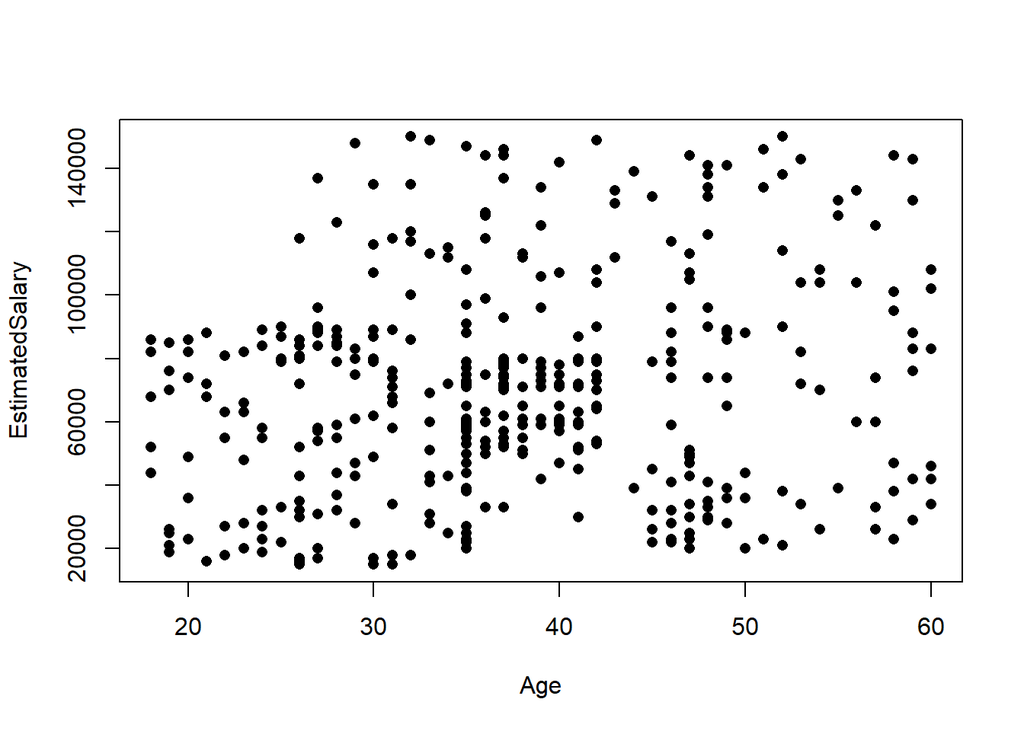

```r
#plotting persebaran data
plot(behaviour, pch=16)
```

Untuk melihat gambaran relasi antar variabel digunakan fungsi pair.

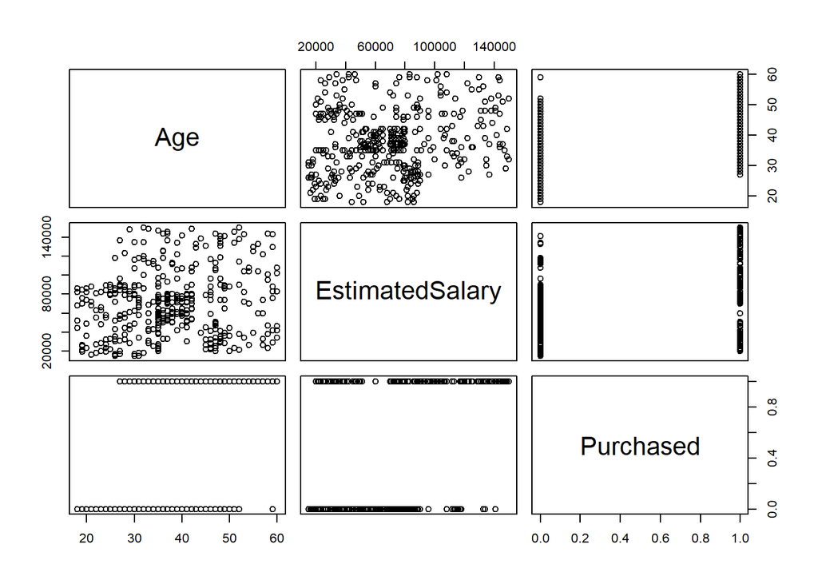

```r
#melihat relasi antar variabel
pairs(myData[, 3:5])
```

Pada data di atas dapat kita lihat bahwa kolom yang akan kita pakai seperti Age, Estimated Salary, dan Purchased merupakan data continuous, terlihat dari summary yang diberikan dari ketiga kolom tersebut berisi nilai minimal, maksimal, median dll padahal data yang dibutuhkan adalah data diskrit. Oleh sebab itu perlu dilakukan Discretization atau merubah data continuous tersebut kedalam kelompok kelas tertentu. Data tersebut akan diubah dalam bentuk factor. Pada data usia (Age) akan dilakukan pengelompokan menjadi 3 kategori usia yaitu Muda mulai dari 18-25 tahun, Dewasa mulai dari 26 - 45 tahun, dan Tua mulai dari 46 - 60 tahun. Kemudian pada Estimated Salary juga akan dibagi menjadi 3 kelompok kelas penghasilan yaitu 15.000 - 50.000 adalah rendah, 50.001 sampai 90.000 adalah menengah, dan 90.001 sampai 150.000 adalah tinggi. Kolom terakhir yang akan diubah bentuk datanya adalah Purchased dengan 0 artinya tidak membeli dan 1 artinya membeli. Selain itu juga akan dilakukan pembersihan data apabila dalam satu baris terdapat kekosongan data.

```r
#mengubah data menjadi factor
myData$Purchased<-factor(myData$Purchased)

#cleaning data : na.omit R function menghapus data yang tidak lengkap
myData = na.omit(myData)
rownames(myData) <- 1:nrow(myData)

#mengubah age menjadi factor dengan ketrangan  <=25 adalah muda, 25 - 45 adalah dewasa, >45 adalah tua
myData$Age[myData$Age <= 25] = "muda"
myData$Age[(myData$Age > 25 & myData$Age <=45)] = "dewasa"
myData$Age[(myData$Age != "muda") & (myData$Age != "dewasa")] = "tua"
myData$Age<-factor(myData$Age)

#mengubah Estimated Salary menjadi factor kemudian dimasukkan dalam 3 kelas penghasilan
myData$EstimatedSalary[myData$EstimatedSalary <= 50000] = "rendah"
myData$EstimatedSalary[(myData$EstimatedSalary > 50000 & myData$EstimatedSalary <=90000)] = "menengah"
myData$EstimatedSalary[(myData$EstimatedSalary != "rendah") & (myData$EstimatedSalary != "menengah")] = "tinggi"
myData$EstimatedSalary<-factor(myData$EstimatedSalary)
```

Lalu dibawah ini merupakan visualisasi variabel-variabel input menggunakan fungsi barplot.

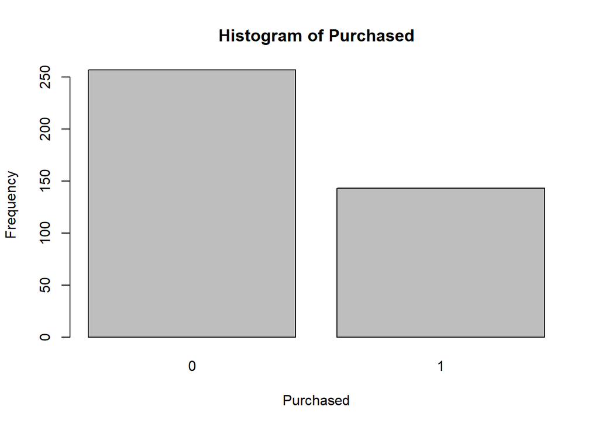

```r
#Plotting histogram dari beberapa variabel-variabel input:
barplot(table(myData$Purchased), xlab="Purchased", ylab="Frequency", main="Histogram of Purchased")
```

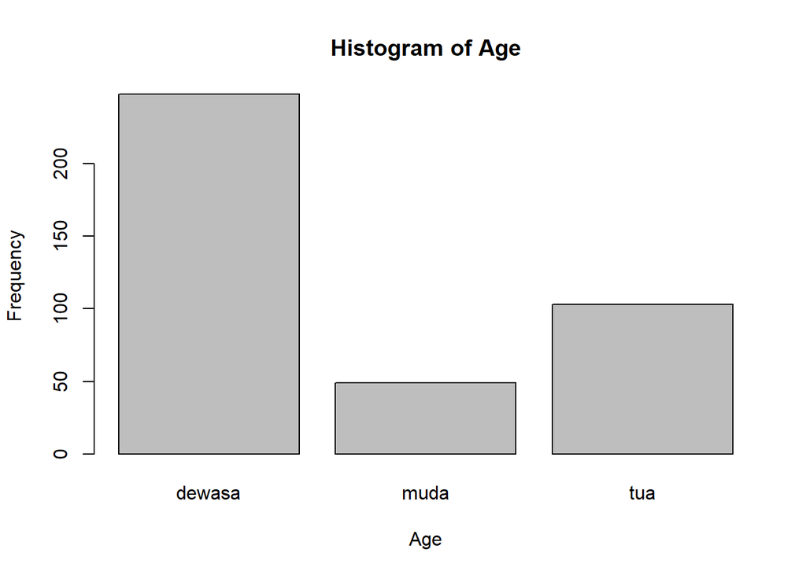

```r
barplot(table(myData$Age), xlab="Age", ylab="Frequency", main="Histogram of Age")
```

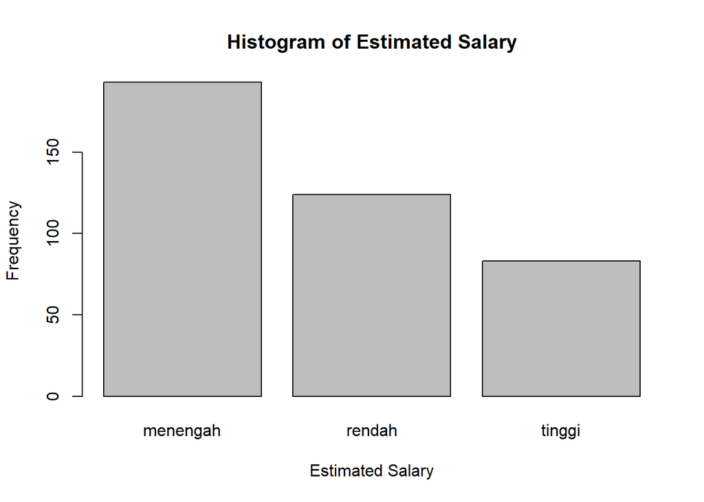

```r
barplot(table(myData$EstimatedSalary), xlab="Estimated Salary", ylab="Frequency", main="Histogram of Estimated Salary")
```

## 2. Pemodelan

## Membuat Train Set dan Test Set

Hal pertama yang dilakukan adalah membuat train set dan test set dengan menggunakan library caret.

```r
#membuat train set dan test set
library(caret)
set.seed(1)
trainIndex <- createDataPartition(myData$Purchased, p = 0.7)$Resample1
train <- myData[trainIndex, ]
test <- myData[-trainIndex, ]
```

Pada trainIndex populasi sampel yang digunakan yaitu 70%.

Selanjutnya untuk melihat dimensi train dan test kita gunakan fungsi dim.

```r
dim(train)
```

```
## [1] 281   5
```

```r
dim(test)
```

```
## [1] 119   5
```

Untuk melihat isi pada table Purchased kita gunakan fungsi print.

```r
print(table(train$Purchased))
```

```
##
##   0   1
## 180 101
```

```r
print(table(test$Purchased))
```

```
##
##  0  1
## 77 42
```

## Memodelkan Naive Bayes Classifier

Langkah selanjutnya adalah melakukan pemodelan naive bayes classifier dengan menggunakan library e1071. Model Naive Bayes yang dibangun adalah untuk memprediksi Purchased dengan menggunakan variabel Age dan Estimated Salary.

```r
#memodelkan dengan naive bayes
library(e1071)
#Prediksi kelas berdasarkan Age dan Estimated Salary
modelNaive1 <- naiveBayes(Purchased ~ Age + EstimatedSalary, data = train)
print(modelNaive1)
```

```
##
## Naive Bayes Classifier for Discrete Predictors
##
## Call:
## naiveBayes.default(x = X, y = Y, laplace = laplace)
##
## A-priori probabilities:
## Y
##         0         1
## 0.6405694 0.3594306
##
## Conditional probabilities:
##    Age
## Y       dewasa       muda        tua
##   0 0.75555556 0.20000000 0.04444444
##   1 0.42574257 0.00000000 0.57425743
##
##    EstimatedSalary
## Y    menengah    rendah    tinggi
##   0 0.6555556 0.2944444 0.0500000
##   1 0.1683168 0.2970297 0.5346535
```

Setelah dilihat dengan fungsi print isi dari modelNaive1 kita mendapatkan conditional probabilities. Untuk yang pertama adalah Y given Age, jadi dapat dilihat bahwa probabilitas dari customer tersebut Tidak membeli(0) dengan melihat kategori umur dewasa adalah 0.75555556, Muda adalah 0.20000000, dan Tua adalah 0.04444444. Untuk customer yang membeli (1) dengan mempertimbangkan kategori usia Dewasa adalah 0.42574257, Muda adalah 0.00000000 dan Tua adalah 0.57425743. Begitu juga pada Y given Estimated Salary.

Setelah kita mendapatkan model, maka tahap selanjutnya adalah mengaplikasikan model tersebut kedalam test set. Fungsi yang digunakan adalah predict.

```r
#aplikasi model ke test set
modelNaive1Pred <- predict(modelNaive1, test)
```

Selanjutnya untuk melakukan evaluasi, kita menggunakan confusion matrix. Dengan cara membandingkan kelas asli dengan kelas predisi.

```r
#gunakan confusion matrix untuk evaluasi
confusionMatrix(test$Purchased, modelNaive1Pred)
```

```
## Confusion Matrix and Statistics
##
##           Reference
## Prediction  0  1
##          0 68  9
##          1  4 38
##
##                Accuracy : 0.8908
##                  95% CI : (0.8204, 0.9405)
##     No Information Rate : 0.605
##     P-Value [Acc > NIR] : 4.024e-12
##
##                   Kappa : 0.7671
##
##  Mcnemar's Test P-Value : 0.2673
##
##             Sensitivity : 0.9444
##             Specificity : 0.8085
##          Pos Pred Value : 0.8831
##          Neg Pred Value : 0.9048
##              Prevalence : 0.6050
##          Detection Rate : 0.5714
##    Detection Prevalence : 0.6471
##       Balanced Accuracy : 0.8765
##
##        'Positive' Class : 0
##
```

## Kesimpulan

Metode Naive Bayes memanfaatkan data training untuk menghasilkan probabilitas setiap kriteria untuk class yang berbeda, sehingga nilai-nilai probabilitas dari kriteria tersebut dapat dioptimalkan untuk memprediksi keputusan pembeli terkait membeli atau tidak membeli terhadap produk tertentu berdasarkan proses klasifikasi yang dilakukan oleh metode Naive Bayes itu sendiri.

Dapat dilihat dari confusion matrix terdapat bagian reference(kondisi aslinya) dan Prediction yaitu prediksi yang kita buat. Pada kondisi saat kita memprediksi customer tidak membeli(0) yaitu sejumlah 68 prediksi benar, pada bagian sebelahnya kita prediksi customer tidak membeli(0) tetapi kenyataanya membeli(1) sejumlah 9. Pada kondisi prediksi customer membeli(1) prediksi benar adalah 38, sebelahnya diprediksi membeli(1) tapi kenyataanya tidak sejumlah 4. Dari prediksi yang dilakukan dengan set.seed(1) akurasi yang didapatkan adalah 0.8908 atau 89% cukup tinggi.